# Synthetic Data

# Synthetic Data

Our goal is to create a set of customer data that looks “real” - either record by record, or as a whole dataset.

## Record Level Synthetic Data

### charlatan

`charlatan` is a package that feels a bit incomplete, but very easily generates a lot of useful sequences of data, from names and phones numbers, latitudes and longitudes, to genetic sequences and scientific names.

For example, here’s synthetic data generated for 10 customers, with:

- Names that might not be clean (e.g. may have titles or qualifications)
- One job that is written in French
- Phone numbers in multiple locales, with missingness
- Credit card numbers

```r
library(charlatan)

set.seed(1)

customers <- data.frame(
  Name = ch_name(10, messy=TRUE),
  Job = c(ch_job(9), ch_job(locale="fr_FR")),
  Contact = MissingDataProvider$new()$make_missing(ch_phone_number(10)),
  CreditCard = ch_credit_card_number(10)
)

customers
```

| Name | Job | Contact | CreditCard |
| --- | --- | --- | --- |
| Channing Glover | Investment banker, corporate | (878)675-9629 | 3447308404399877 |
| Heather Ziemann | IT technical support officer | (711)550-2275 | 3455117397447760 |
| Ballard Wyman | Sound technician, broadcasting/film/video | 1-576-037-8863x65045 | 4093888855322 |
| Carli McDermott | Paramedic | NA | 4886846339709193 |
| Landyn Predovic | Clinical cytogeneticist | 1-979-467-4570x292 | 501834458740106 |
| Mrs. Ingeborg King | Nurse, mental health | 1-055-384-0252 | 210079661831413252 |
| Eileen Klocko | Scientist, physiological | 1-220-817-5016 | 3158644009029630863 |
| Cannon Hegmann | Research officer, political party | 1-638-724-2310x689 | 6011312956006026146 |
| Nichelle Schoen | Special effects artist | 911-201-2227x819 | 3096971378507885726 |
| Earley Monahan | Illustrateur | 934.846.4531x02785 | 4033074492864232 |

## Dataset Level Synthetic Data

### fabricatr

`fabricatr` enables simple relationships between variables to be specified, but needs some effort put in.

For each of the 10 customers above we’ll generate 10 transactions:

- Uniformly distributed throughout the year
- Where each customer generally increases their payments through the year,
- Where each customer has a general level of payment, and
- The minimum payment is approximately 5

|  | ID | Name | DayOfYear | Payment |
| --- | --- | --- | --- | --- |
| 55 | 055 | Landyn Predovic | 27 | 8.33 |
| 5 | 005 | Landyn Predovic | 75 | 10.83 |
| 92 | 092 | Heather Ziemann | 23 | 13.08 |
| 15 | 015 | Landyn Predovic | 282 | 13.92 |
| 85 | 085 | Landyn Predovic | 278 | 15.61 |
| 51 | 051 | Channing Glover | 176 | 15.64 |
| 45 | 045 | Landyn Predovic | 195 | 17.33 |
| 25 | 025 | Landyn Predovic | 99 | 17.51 |
| 98 | 098 | Cannon Hegmann | 151 | 24.22 |
| 95 | 095 | Landyn Predovic | 286 | 24.94 |

[output cut: 90 more lines]

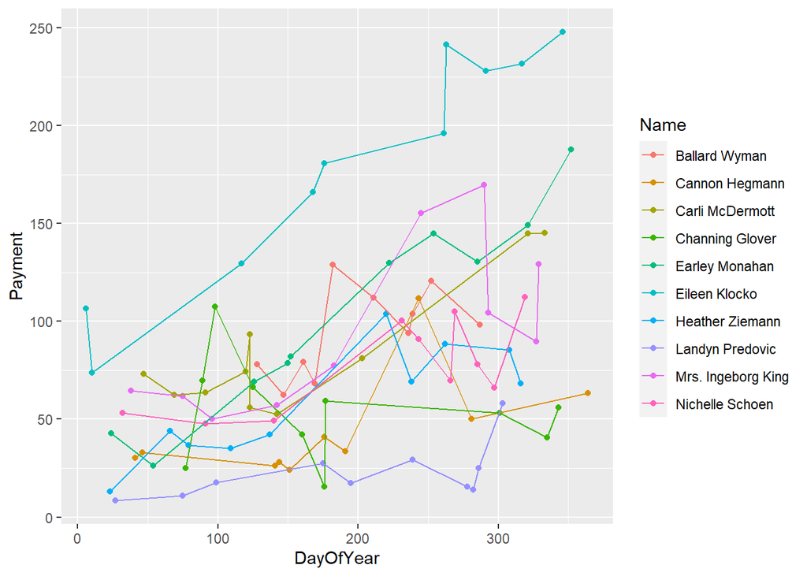

```r
library(fabricatr)

set.seed(1)

customer_transactions <- fabricate(
  N = 100,
  Name = rep(customers$Name, 10),
  DayOfYear = draw_categorical(prob=matrix(1/365, 100, 365)),
  Payment = round(
    draw_normal_icc(
      mean = 5,
      sd = 1,
      N = N,
      clusters = Name,
      ICC = 0.9)
    * DayOfYear/20 +
    pmax(
      draw_normal_icc(
        mean = 20,
        sd = 20,
        N = N,
        clusters = Name,
        ICC = 0.6),
      5 + rgamma(100, 1)
      ),
    2)
)

customer_transactions[order(customer_transactions$Payment),]
```

## synthpop

`synthpop` also generates synthetic datasets, but in a very straightforward way - taking a sample dataset and producing a dataset that looks pretty similar to the sample data.

Below we try this on the transactions dataset that was generated above.

```r
library(synthpop)
customer_transactions2 <- syn(customer_transactions[,-1], seed = 1)$syn
```

```
## CAUTION: Your data set has fewer observations (100) than we advise.
## We suggest that there should be at least 130 observations
## (100 + 10 * no. of variables used in modelling the data).
## Please check your synthetic data carefully with functions
## compare(), utility.tab(), and utility.gen().
##
##
## Variable(s): Name have been changed for synthesis from character to factor.
##
## Synthesis
## -----------
##  Name DayOfYear Payment
```

```r
customer_transactions2[order(customer_transactions2$Payment),]
```

|  | Name | DayOfYear | Payment |
| --- | --- | --- | --- |
| 19 | Landyn Predovic | 75 | 17.33 |
| 29 | Landyn Predovic | 286 | 17.33 |
| 56 | Landyn Predovic | 286 | 17.33 |
| 77 | Landyn Predovic | 303 | 17.33 |
| 98 | Landyn Predovic | 75 | 17.51 |
| 75 | Cannon Hegmann | 144 | 24.22 |
| 12 | Landyn Predovic | 75 | 24.94 |
| 52 | Landyn Predovic | 99 | 24.94 |
| 10 | Channing Glover | 160 | 25.12 |
| 45 | Channing Glover | 176 | 25.12 |

[output cut: 90 more lines]

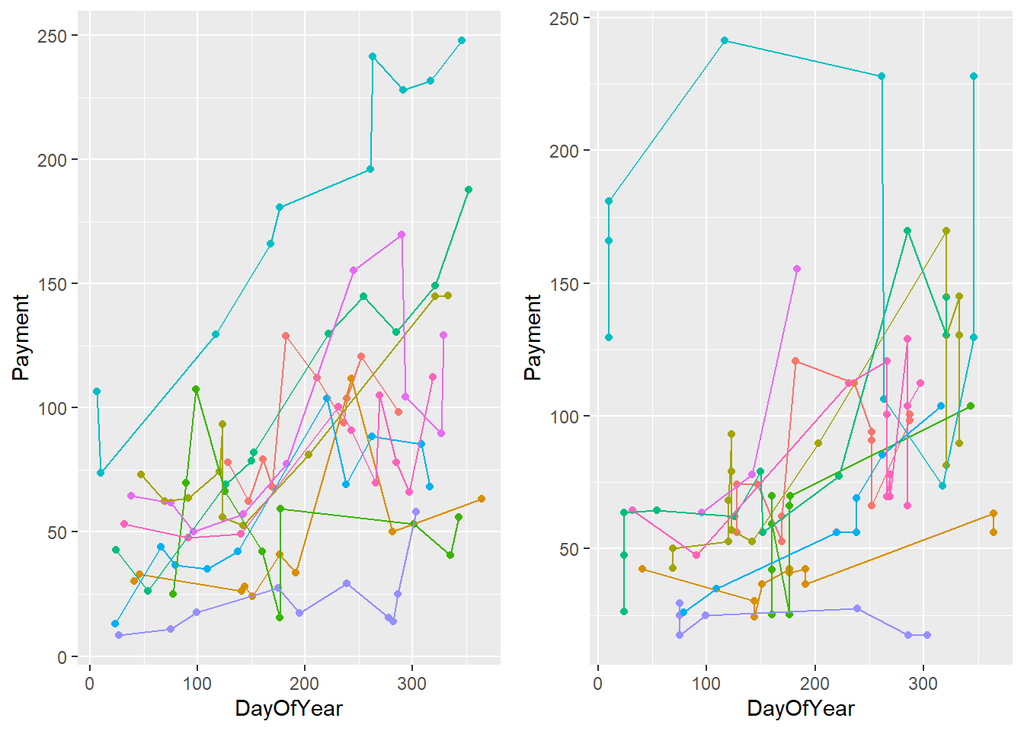